# RQ4 analysis

Author

Risk Rejection Team: Guannan Shen

Published

September 23, 2024

# Data Filtering Process

[figure not shown]

# Data Quality Assurance

The filtered dataset used here contains **527 subjects** and 505 columns.

## Missingness Check and Descriptive Analysis

### Missingness

Check Missingness: Risks Comprehension and Obj Nums

| Columns | Missing_Count | Missing_percentage |
| --- | --- | --- |
| ObjNum1 | 44 | 8.35% |
| ObjNum2 | 44 | 8.35% |
| ObjNum3 | 44 | 8.35% |
| RiskComp1 | 37 | 7.02% |
| RiskComp2 | 37 | 7.02% |
| RReject2 | 2 | 0.38% |
| RReject1 | 0 | 0% |
| RReject3 | 0 | 0% |
| RReject4 | 0 | 0% |
| RReject5 | 0 | 0% |
| RReject6 | 0 | 0% |
| RReject7 | 0 | 0% |

### Descriptive Analysis

#### Frequency Table for RReject1

Frequency and Percentage of RReject1

| RReject1 | Frequency Count | Percentage (%) |
| --- | --- | --- |
| 0 | 44 | 8.349 |
| 0.008 | 1 | 0.190 |
| 0.011 | 1 | 0.190 |
| 0.5 | 1 | 0.190 |
| 1 | 25 | 4.744 |
| 2 | 4 | 0.759 |
| 3 | 5 | 0.949 |
| 4 | 1 | 0.190 |
| 5 | 29 | 5.503 |
| 6 | 4 | 0.759 |
| 7 | 10 | 1.898 |
| 8 | 11 | 2.087 |
| 9 | 12 | 2.277 |
| 10 | 73 | 13.852 |
| 11 | 14 | 2.657 |
| 12 | 15 | 2.846 |
| 13 | 7 | 1.328 |
| 14 | 10 | 1.898 |
| 15 | 29 | 5.503 |
| 16 | 12 | 2.277 |
| 17 | 4 | 0.759 |
| 18 | 4 | 0.759 |
| 19 | 7 | 1.328 |
| 20 | 40 | 7.590 |
| 21 | 7 | 1.328 |
| 22 | 7 | 1.328 |
| 23 | 3 | 0.569 |
| 24 | 14 | 2.657 |
| 25 | 17 | 3.226 |
| 26 | 2 | 0.380 |
| 27 | 1 | 0.190 |
| 28 | 4 | 0.759 |
| 29 | 2 | 0.380 |
| 30 | 12 | 2.277 |
| 31 | 1 | 0.190 |
| 34 | 1 | 0.190 |
| 35 | 1 | 0.190 |
| 36 | 2 | 0.380 |
| 37 | 1 | 0.190 |
| 40 | 7 | 1.328 |
| 41 | 1 | 0.190 |
| 42 | 1 | 0.190 |
| 43 | 1 | 0.190 |
| 44 | 1 | 0.190 |
| 45 | 2 | 0.380 |
| 46 | 3 | 0.569 |
| 47 | 1 | 0.190 |
| 50 | 17 | 3.226 |
| 57 | 1 | 0.190 |
| 59 | 1 | 0.190 |
| 60 | 4 | 0.759 |
| 61 | 1 | 0.190 |
| 75 | 1 | 0.190 |
| 76 | 1 | 0.190 |
| 85 | 1 | 0.190 |
| 90 | 1 | 0.190 |
| 94 | 1 | 0.190 |
| 99 | 1 | 0.190 |
| 100 | 19 | 3.605 |
| 200 | 1 | 0.190 |
| 300 | 1 | 0.190 |
| 383 | 1 | 0.190 |
| 400 | 2 | 0.380 |
| 500 | 8 | 1.518 |
| 700 | 1 | 0.190 |
| 900 | 2 | 0.380 |
| 1000 | 6 | 1.139 |
| 10000 | 1 | 0.190 |
| Sum | 527 | 100.000 |

#### Descriptive Summary of RReject1

Descriptive Summary of RReject1

| mean | median | min | max | variance | sd | n_missing |
| --- | --- | --- | --- | --- | --- | --- |
| 64.56455 | 14 | 0 | 10000 | 207116.7 | 455.1007 | 0 |

#### Frequency Table for RReject2

Frequency and Percentage of RReject2

| RReject2 | Frequency Count | Percentage (%) |
| --- | --- | --- |
| 1 | 1 | 0.190 |
| 10 | 1 | 0.190 |
| 100 | 1 | 0.190 |
| 1000 | 1 | 0.190 |
| 17 | 1 | 0.190 |
| 39 out of 1,000 seemed like a low number. I just rounded the number to the nearest 100th. I have no real basis for this answer, it's just a random number. | 1 | 0.190 |
| 5 | 1 | 0.190 |
| 6 | 1 | 0.190 |
| 60 | 1 | 0.190 |
| 89 | 1 | 0.190 |
| A lot of these diseases are hereditary but not to say I'm immune. There are women who get breast cancer and it's not hereditary. I like to hope for the best, positive vibes. | 1 | 0.190 |
| After reading the estimate, I concluded that I have no guess whatsoever, so I had to go with the estimate. | 1 | 0.190 |
| Age and race | 1 | 0.190 |
| Age and regular mammograms | 1 | 0.190 |
| Almost same | 1 | 0.190 |
| Although my grandmother had breast cancer, my mom did not. So, my chances should be a little bit lower. | 1 | 0.190 |
| As you age, the risk may increase due to genetics. | 1 | 0.190 |
| At my age I feel if there was a higher risk I would have had indicators | 1 | 0.190 |
| aunt had breast cancer | 1 | 0.190 |
| Average | 1 | 0.190 |
| Based on the history and close relatives, including my health habits, I think my risk is low. | 1 | 0.190 |
| Based on what I eat, do and daily activities too | 1 | 0.190 |
| Bc in my family I have no history of breast cancer | 1 | 0.190 |
| Because I take care of my self and no history of cancer in my family | 1 | 0.190 |
| Because a lot more people are being diagnosed with cancer | 1 | 0.190 |
| Because a lot women use medicine too much | 1 | 0.190 |
| Because alot more of my female family members are developing breast cancer at a enormous rate. | 1 | 0.190 |
| Because breast cancer doesn’t run high in my family | 1 | 0.190 |
| Because cancer runs in my family just not breast cancer. | 1 | 0.190 |
| because for my age it is 6 out of 1000 | 1 | 0.190 |

[output cut: 483 more lines]

#### Descriptive Summary of RReject2

Descriptive Summary of RReject2

| mean | median | min | max | variance | sd | n_missing |
| --- | --- | --- | --- | --- | --- | --- |
| NA | I have 3 sisters and my mother. All my sisters are in their 70 and one in her 80’s. Our mother passed at age 86. None of us has experienced breast cancer. | 1 | Your mother have breast cancer and my grandmother have breast cancer | 104705.6 | 323.5825 | 2 |

#### Frequency Table for RReject3

Frequency and Percentage of RReject3

| RReject3 | Frequency Count | Percentage (%) |
| --- | --- | --- |
| 1 | 106 | 20.114 |
| 2 | 254 | 48.197 |
| 3 | 167 | 31.689 |
| Sum | 527 | 100.000 |

#### Descriptive Summary of RReject3

Descriptive Summary of RReject3

| mean | median | min | max | variance | sd | n_missing |
| --- | --- | --- | --- | --- | --- | --- |
| 2.11575 | 2 | 1 | 3 | 0.505588 | 0.7110471 | 0 |

#### Frequency Table for RReject4

Frequency and Percentage of RReject4

| RReject4 | Frequency Count | Percentage (%) |
| --- | --- | --- |
| 1 | 56 | 10.626 |
| 2 | 66 | 12.524 |
| 3 | 160 | 30.361 |
| 4 | 134 | 25.427 |
| 7 | 111 | 21.063 |
| Sum | 527 | 100.000 |

#### Descriptive Summary of RReject4

Descriptive Summary of RReject4

| mean | median | min | max | variance | sd | n_missing |
| --- | --- | --- | --- | --- | --- | --- |
| 3.759013 | 3 | 1 | 7 | 3.605313 | 1.898766 | 0 |

#### Frequency Table for RReject5

Frequency and Percentage of RReject5

| RReject5 | Frequency Count | Percentage (%) |
| --- | --- | --- |
| 1 | 44 | 8.349 |
| 2 | 44 | 8.349 |
| 3 | 137 | 25.996 |
| 4 | 176 | 33.397 |
| 7 | 126 | 23.909 |
| Sum | 527 | 100.000 |

#### Descriptive Summary of RReject5

Descriptive Summary of RReject5

| mean | median | min | max | variance | sd | n_missing |
| --- | --- | --- | --- | --- | --- | --- |
| 4.039848 | 4 | 1 | 7 | 3.502211 | 1.87142 | 0 |

#### Frequency Table for RReject6

Frequency and Percentage of RReject6

| RReject6 | Frequency Count | Percentage (%) |
| --- | --- | --- |
| 1 | 46 | 8.729 |
| 2 | 48 | 9.108 |
| 3 | 156 | 29.602 |
| 4 | 151 | 28.653 |
| 7 | 126 | 23.909 |
| Sum | 527 | 100.000 |

#### Descriptive Summary of RReject6

Descriptive Summary of RReject6

| mean | median | min | max | variance | sd | n_missing |
| --- | --- | --- | --- | --- | --- | --- |
| 3.97723 | 4 | 1 | 7 | 3.604043 | 1.898432 | 0 |

#### Frequency Table for RReject7

Frequency and Percentage of RReject7

| RReject7 | Frequency Count | Percentage (%) |
| --- | --- | --- |
| 1 | 48 | 9.108 |
| 2 | 64 | 12.144 |
| 3 | 158 | 29.981 |
| 4 | 154 | 29.222 |
| 7 | 103 | 19.545 |
| Sum | 527 | 100.000 |

#### Descriptive Summary of RReject7

Descriptive Summary of RReject7

| mean | median | min | max | variance | sd | n_missing |
| --- | --- | --- | --- | --- | --- | --- |
| 3.770398 | 3 | 1 | 7 | 3.317905 | 1.821512 | 0 |

#### Frequency Table for RiskComp1

Frequency and Percentage of RiskComp1

| RiskComp1 | Frequency Count | Percentage (%) |
| --- | --- | --- |
| 1 | 252 | 47.818 |
| 2 | 179 | 33.966 |
| 4 | 59 | 11.195 |
| NA | 37 | 7.021 |
| Sum | 527 | 100.000 |

#### Descriptive Summary of RiskComp1

Descriptive Summary of RiskComp1

| mean | median | min | max | variance | sd | n_missing |
| --- | --- | --- | --- | --- | --- | --- |
| 1.726531 | 1 | 1 | 4 | 0.9230166 | 0.9607375 | 37 |

#### Frequency Table for RiskComp2

Frequency and Percentage of RiskComp2

| RiskComp2 | Frequency Count | Percentage (%) |
| --- | --- | --- |
| 1 | 231 | 43.833 |
| 2 | 220 | 41.746 |
| 4 | 39 | 7.400 |
| NA | 37 | 7.021 |
| Sum | 527 | 100.000 |

#### Descriptive Summary of RiskComp2

Descriptive Summary of RiskComp2

| mean | median | min | max | variance | sd | n_missing |
| --- | --- | --- | --- | --- | --- | --- |
| 1.687755 | 2 | 1 | 4 | 0.6937148 | 0.8328954 | 37 |

#### Frequency Table for ObjNum1

Frequency and Percentage of ObjNum1

| ObjNum1 | Frequency Count | Percentage (%) |
| --- | --- | --- |
| 0 | 4 | 0.759 |
| 1 | 3 | 0.569 |
| 2 | 2 | 0.380 |
| 3 | 2 | 0.380 |
| 4 | 1 | 0.190 |
| 5 | 6 | 1.139 |
| 6 | 1 | 0.190 |
| 8 | 1 | 0.190 |
| 9 | 1 | 0.190 |
| 10 | 20 | 3.795 |
| 12 | 1 | 0.190 |
| 14 | 1 | 0.190 |
| 15 | 2 | 0.380 |
| 17 | 1 | 0.190 |
| 20 | 8 | 1.518 |
| 21 | 2 | 0.380 |
| 24 | 1 | 0.190 |
| 25 | 7 | 1.328 |
| 30 | 4 | 0.759 |
| 40 | 3 | 0.569 |
| 42 | 1 | 0.190 |
| 45 | 4 | 0.759 |
| 50 | 61 | 11.575 |
| 54.3 | 1 | 0.190 |
| 55 | 1 | 0.190 |
| 58 | 1 | 0.190 |
| 60 | 4 | 0.759 |
| 65 | 2 | 0.380 |
| 67 | 1 | 0.190 |
| 70 | 1 | 0.190 |
| 80 | 1 | 0.190 |
| 100 | 11 | 2.087 |
| 190 | 1 | 0.190 |
| 200 | 4 | 0.759 |
| 250 | 4 | 0.759 |
| 300 | 1 | 0.190 |
| 340 | 1 | 0.190 |
| 367 | 1 | 0.190 |
| 400 | 4 | 0.759 |
| 450 | 4 | 0.759 |
| 476 | 1 | 0.190 |
| 485 | 1 | 0.190 |
| 499 | 1 | 0.190 |
| 500 | 247 | 46.869 |
| 525 | 1 | 0.190 |
| 543 | 1 | 0.190 |
| 550 | 1 | 0.190 |
| 600 | 9 | 1.708 |
| 609 | 1 | 0.190 |
| 650 | 1 | 0.190 |
| 670 | 1 | 0.190 |
| 700 | 2 | 0.380 |
| 750 | 2 | 0.380 |
| 767 | 1 | 0.190 |
| 795 | 1 | 0.190 |
| 999 | 1 | 0.190 |
| 1000 | 21 | 3.985 |
| 1050 | 1 | 0.190 |
| 2500 | 1 | 0.190 |
| 5000 | 3 | 0.569 |
| 5000.1 | 1 | 0.190 |
| 50010 | 2 | 0.380 |
| 5e+05 | 1 | 0.190 |
| 501000 | 1 | 0.190 |
| NA | 44 | 8.349 |
| Sum | 527 | 100.000 |

#### Descriptive Summary of ObjNum1

Descriptive Summary of ObjNum1

| mean | median | min | max | variance | sd | n_missing |
| --- | --- | --- | --- | --- | --- | --- |
| 2686.222 | 500 | 0 | 501000 | 1042989303 | 32295.34 | 44 |

#### Frequency Table for ObjNum2

Frequency and Percentage of ObjNum2

| ObjNum2 | Frequency Count | Percentage (%) |
| --- | --- | --- |
| 0 | 6 | 1.139 |
| 0.001 | 1 | 0.190 |
| 0.01 | 2 | 0.380 |
| 0.05 | 1 | 0.190 |
| 0.1 | 3 | 0.569 |
| 0.5 | 1 | 0.190 |
| 1 | 97 | 18.406 |
| 2 | 1 | 0.190 |
| 3 | 3 | 0.569 |
| 5 | 9 | 1.708 |
| 6 | 3 | 0.569 |
| 7 | 3 | 0.569 |
| 8 | 2 | 0.380 |
| 9 | 1 | 0.190 |
| 9.999 | 1 | 0.190 |
| 10 | 255 | 48.387 |
| 11 | 1 | 0.190 |
| 14 | 1 | 0.190 |
| 15 | 1 | 0.190 |
| 19 | 1 | 0.190 |
| 20 | 9 | 1.708 |
| 21 | 1 | 0.190 |
| 25 | 2 | 0.380 |
| 28 | 1 | 0.190 |
| 50 | 9 | 1.708 |
| 60 | 1 | 0.190 |
| 80 | 2 | 0.380 |
| 90 | 1 | 0.190 |
| 100 | 40 | 7.590 |
| 101 | 3 | 0.569 |
| 193 | 1 | 0.190 |
| 200 | 1 | 0.190 |
| 300 | 1 | 0.190 |
| 400 | 1 | 0.190 |
| 500 | 4 | 0.759 |
| 700 | 1 | 0.190 |
| 999 | 2 | 0.380 |
| 1000 | 8 | 1.518 |
| 1010 | 1 | 0.190 |
| 11000 | 1 | 0.190 |
| NA | 44 | 8.349 |
| Sum | 527 | 100.000 |

#### Descriptive Summary of ObjNum2

Descriptive Summary of ObjNum2

| mean | median | min | max | variance | sd | n_missing |
| --- | --- | --- | --- | --- | --- | --- |
| 70.3517 | 10 | 0 | 11000 | 273763.1 | 523.2237 | 44 |

#### Frequency Table for ObjNum3

Frequency and Percentage of ObjNum3

| ObjNum3 | Frequency Count | Percentage (%) |
| --- | --- | --- |
| 0 | 5 | 0.949 |
| 1e-04 | 2 | 0.380 |
| 0.001 | 18 | 3.416 |
| 0.01 | 23 | 4.364 |
| 0.02 | 2 | 0.380 |
| 0.05 | 3 | 0.569 |
| 0.1 | 63 | 11.954 |
| 0.2 | 1 | 0.190 |
| 0.5 | 8 | 1.518 |
| 1 | 162 | 30.740 |
| 2 | 2 | 0.380 |
| 3 | 3 | 0.569 |
| 4 | 1 | 0.190 |
| 5 | 10 | 1.898 |
| 8 | 1 | 0.190 |
| 9.999 | 1 | 0.190 |
| 10 | 106 | 20.114 |
| 12 | 1 | 0.190 |
| 14 | 1 | 0.190 |
| 15 | 4 | 0.759 |
| 20 | 6 | 1.139 |
| 21 | 1 | 0.190 |
| 25 | 3 | 0.569 |
| 28 | 1 | 0.190 |
| 30 | 1 | 0.190 |
| 33 | 1 | 0.190 |
| 40 | 2 | 0.380 |
| 49 | 1 | 0.190 |
| 50 | 10 | 1.898 |
| 70 | 1 | 0.190 |
| 75 | 1 | 0.190 |
| 80 | 1 | 0.190 |
| 90 | 3 | 0.569 |
| 99 | 1 | 0.190 |
| 100 | 19 | 3.605 |
| 150 | 1 | 0.190 |
| 200 | 1 | 0.190 |
| 300 | 2 | 0.380 |
| 500 | 4 | 0.759 |
| 900 | 1 | 0.190 |
| 999 | 2 | 0.380 |
| 1000 | 3 | 0.569 |
| NA | 44 | 8.349 |
| Sum | 527 | 100.000 |

#### Descriptive Summary of ObjNum3

Descriptive Summary of ObjNum3

| mean | median | min | max | variance | sd | n_missing |
| --- | --- | --- | --- | --- | --- | --- |
| 28.32699 | 1 | 0 | 1000 | 14424.31 | 120.1013 | 44 |

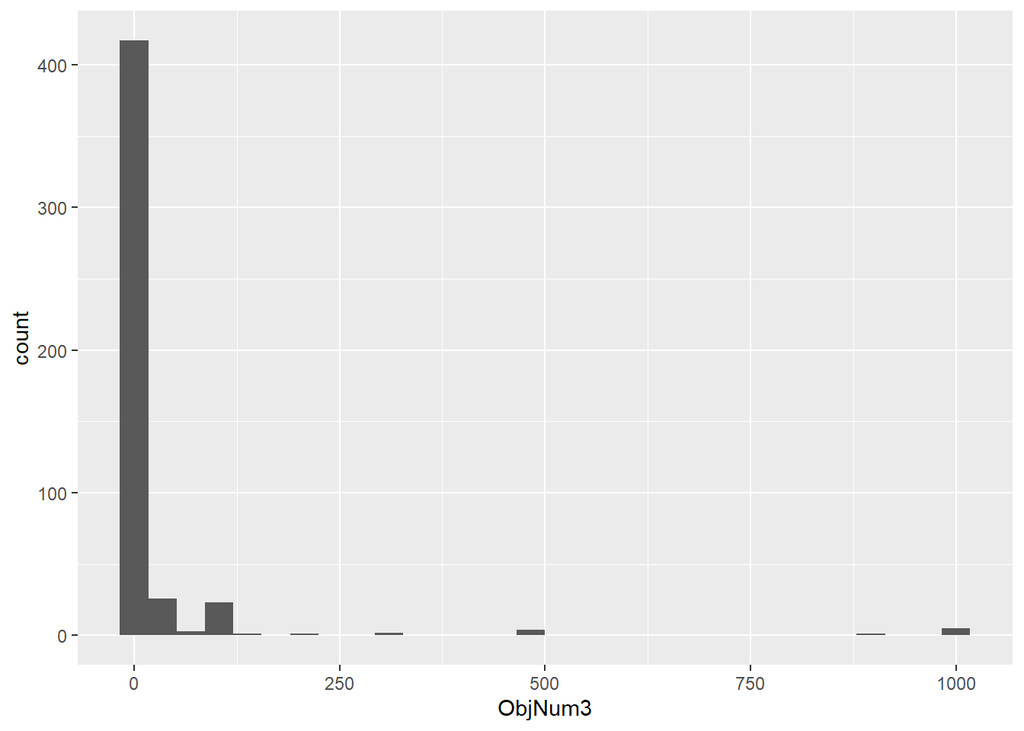

## Check Related Variables

Cross-Frequency Table Between Bayesian1 and missingness_Bayesian1a

| Bayesian1 | missingness_Bayesian1a missing | missingness_Bayesian1a nonmissing | missingness_Bayesian1a Sum |
| --- | --- | --- | --- |
| X0 | 324 | 0 | 324 |
| X1 | 1 | 193 | 194 |
| NA. | 9 | 0 | 9 |
| Sum | 334 | 193 | 527 |

Cross-Frequency Table Between Bayesian2 and missingness_Bayesian2a

| Bayesian2 | missingness_Bayesian2a missing | missingness_Bayesian2a nonmissing | missingness_Bayesian2a Sum |
| --- | --- | --- | --- |
| X0 | 498 | 0 | 498 |
| X1 | 0 | 20 | 20 |
| NA. | 9 | 0 | 9 |
| Sum | 507 | 20 | 527 |

# Reseach Question 4

How do different methods for identifying potential inattentive responders perform?

## Indicators Breakdown

- Create Speeder flag (1 = Speeder, 0 = Not Speeder), according to 0.5 * median_duration.
- Create Attflag1 (1 = pass, 0 = fail for AttCheck1).
- Create Attflag2 (1 = pass, 0 = fail for AttCheck2).
- Create Attcount1 (sum of Attflag1 and Attflag2), count of passed attention checks (either 0, 1, or 2).
- Create Attcount2 (sum of Attflag1, Attflag2, and Use_of_data), count of passed attention checks and the use of data flag (0 to 3).

Descriptive Summary of Duration (in seconds)

| mean | median | min | max | variance | sd | n_missing |
| --- | --- | --- | --- | --- | --- | --- |
| 1659.573 | 1315 | 180 | 23179 | 3573897 | 1890.475 | 0 |

## Questions Breakdown

We want to see the frequencies (and %) for each of the 3 criteria:

1. How many are speeding?
2. How many answer each of the directed questions incorrectly? And then a count of how many they answered correct/incorrect (0/1/2).
3. How many answer the self-reported “in your honest opinion” that we should not use their data.
4. Between speeders, “don’t use my data” (Q8 Use of data), and incorrectly answered 2/2 directed questions. Please provide frequencies and % for all.
5. Also compute how many people miss at least 1 of the 3 criteria, and a frequency (and %) of how many people miss 0 vs 1 vs 2 vs 3 criteria

### Frequency Table for Use_of_data

Frequency and Percentage of Use_of_data

| Use_of_data | Frequency Count | Percentage (%) |
| --- | --- | --- |
| Not use data | 49 | 9.298 |
| Use data | 430 | 81.594 |
| NA | 48 | 9.108 |
| Sum | 527 | 100.000 |

### Frequency Table for Speeder

Frequency and Percentage of Speeder

| Speeder | Frequency Count | Percentage (%) |
| --- | --- | --- |
| Not Speeder | 487 | 92.410 |
| Speeder | 40 | 7.590 |
| Sum | 527 | 100.000 |

### Frequency Table for Attflag1

Frequency and Percentage of Attflag1

| Attflag1 | Frequency Count | Percentage (%) |
| --- | --- | --- |
| Fail | 58 | 11.006 |
| Pass | 439 | 83.302 |
| NA | 30 | 5.693 |
| Sum | 527 | 100.000 |

### Frequency Table for Attflag2

Frequency and Percentage of Attflag2

| Attflag2 | Frequency Count | Percentage (%) |
| --- | --- | --- |
| Fail | 37 | 7.021 |
| Pass | 456 | 86.528 |
| NA | 34 | 6.452 |
| Sum | 527 | 100.000 |

### Frequency Table for Attcount1

Frequency and Percentage of Attcount1

| Attcount1 | Frequency Count | Percentage (%) |
| --- | --- | --- |
| Fail both | 29 | 5.503 |
| Pass 1 | 35 | 6.641 |
| Pass both | 425 | 80.645 |
| NA | 38 | 7.211 |
| Sum | 527 | 100.000 |

### Frequency Table for Attcount2

Frequency and Percentage of Attcount2

| Attcount2 | Frequency Count | Percentage (%) |
| --- | --- | --- |
| Fail all | 10 | 1.898 |
| Pass 1 | 22 | 4.175 |
| Pass 2 | 61 | 11.575 |
| Pass all | 381 | 72.296 |
| NA | 53 | 10.057 |
| Sum | 527 | 100.000 |

### Cross-frequency Tables Between Speeder and Attention Flags

Cross-Frequency Table Between Use_of_data and Speeder

| Use_of_data | Speeder Not Speeder | Speeder | Speeder Sum |
| --- | --- | --- | --- |
| Not.use.data | 43 | 6 | 49 |
| Use.data | 414 | 16 | 430 |
| NA. | 30 | 18 | 48 |
| Sum | 487 | 40 | 527 |

Cross-Frequency Table Between Attcount1 and Speeder

| Attcount1 | Speeder Not Speeder | Speeder | Speeder Sum |
| --- | --- | --- | --- |
| Fail.both | 27 | 2 | 29 |
| Pass.1 | 31 | 4 | 35 |
| Pass.both | 410 | 15 | 425 |
| NA. | 19 | 19 | 38 |
| Sum | 487 | 40 | 527 |

Cross-Frequency Table Between Attcount2 and Speeder

| Attcount2 | Speeder Not Speeder | Speeder | Speeder Sum |
| --- | --- | --- | --- |
| Fail.all | 8 | 2 | 10 |
| Pass.1 | 21 | 1 | 22 |
| Pass.2 | 55 | 6 | 61 |
| Pass.all | 369 | 12 | 381 |
| NA. | 34 | 19 | 53 |
| Sum | 487 | 40 | 527 |

Percentage (%) Cross-Frequency Table Between Use_of_data and Speeder

| Use_of_data | Speeder Not Speeder | Speeder | Speeder Sum |
| --- | --- | --- | --- |
| Not.use.data | 8.16 | 1.14 | 9.30 |
| Use.data | 78.56 | 3.04 | 81.59 |
| NA. | 5.69 | 3.42 | 9.11 |
| Sum | 92.41 | 7.59 | 100.00 |

Percentage (%) Cross-Frequency Table Between Attcount1 and Speeder

| Attcount1 | Speeder Not Speeder | Speeder | Speeder Sum |
| --- | --- | --- | --- |
| Fail.both | 5.12 | 0.38 | 5.50 |
| Pass.1 | 5.88 | 0.76 | 6.64 |
| Pass.both | 77.80 | 2.85 | 80.65 |
| NA. | 3.61 | 3.61 | 7.21 |
| Sum | 92.41 | 7.59 | 100.00 |

Percentage (%) Cross-Frequency Table Between Attcount2 and Speeder

| Attcount2 | Speeder Not Speeder | Speeder | Speeder Sum |
| --- | --- | --- | --- |
| Fail.all | 1.52 | 0.38 | 1.90 |
| Pass.1 | 3.98 | 0.19 | 4.17 |
| Pass.2 | 10.44 | 1.14 | 11.57 |
| Pass.all | 70.02 | 2.28 | 72.30 |
| NA. | 6.45 | 3.61 | 10.06 |
| Sum | 92.41 | 7.59 | 100.00 |